# Lab #1

Lab Group 11

January 28, 2019

## Deliverable 2

Several packages needed to be installed (it’s strange there isn’t a check in the code that sees if you have the needed libraries, and installs them if not). That was easy to fix. But Gina (other people should chime in) got an error `Rcpp.Rmd` file.

I had an issue in installing a package called `emo`. When I was trying to use `install.package()`, it says “package `emo` is not available”. So I searched it on google and found that `emo` package is not available on cran. I need to install it from github using package `devtools`.

After I updated and installed some packages, I have an error: `'err' inherits from 'warning/condition' not 'error_bad_argument'`. `Execution halted Error in Rscript_render(f, render_args, render_meta)` `Failed to compile Conditions.Rmd Calls: <Anonymous> -> render_new_session _> Rscript_render Execution halted`. I decided to quit. But the Next day after I restarted my labtop, I encounter the same error with Dapeng, about the “emo” package. So I used devtools to install `emo` according to his approach. Finally, I get the book! (`install.packages("devtools")`, `devtools::install_github("hadley/emo"))`

```r
weather <- read_fwf("ftp://ftp.ncdc.noaa.gov/pub/data/ushcn/v2.5/ushcn-v2.5-stations.txt",col_positions = fwf_widths(c(2,1,2,6,9,10,7,3,31,7,7,7,3),col_names = c("COUNTRY CODE ", "NETWORK CODE","ID PLACEHOLDERS (\"00\")","COOP ID", "LATITUDE", "LONGITUDE", "ELEVATION","STATE", "NAME", "COMPONENT 1 (COOP ID)","COMPONENT 2 (COOP ID)","COMPONENT 3 (COOP ID)", "UTC OFFSET")))
```

## Weather deliverables

Download data and familiarize ourselves with read_fwf

Note that the widths and column names are derived from the the weather-readme.txt

```r
weather <- read_fwf("ftp://ftp.ncdc.noaa.gov/pub/data/ushcn/v2.5/ushcn-v2.5-stations.txt",
                    col_positions = fwf_widths(c(2, 1, 2, 6, 9, 10, 7, 3, 31, 7, 7, 7, 3),
                                               col_names = c("COUNTRY CODE ",
                                                             "NETWORK CODE",
                                                             "ID PLACEHOLDERS (\"00\")",
                                                             "COOP ID",
                                                             "LATITUDE",
                                                             "LONGITUDE",
                                                             "ELEVATION",
                                                             "STATE",
                                                             "NAME",
                                                             "COMPONENT 1 (COOP ID)",
                                                             "COMPONENT 2 (COOP ID)",
                                                             "COMPONENT 3 (COOP ID)",
                                                             "UTC OFFSET")))
```

The formats of all columns are exactly the intended format. Good job tibble.

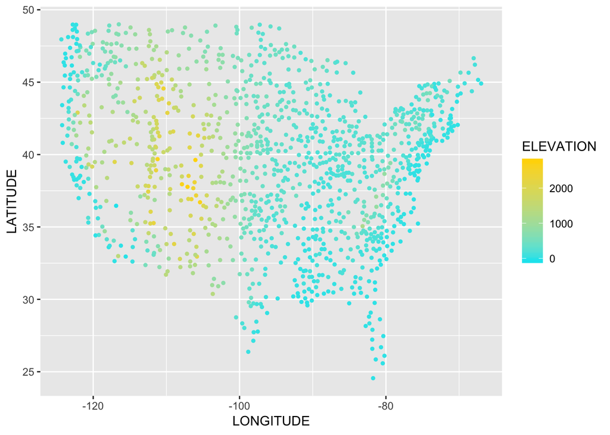

```r
weather %>% ggplot(aes(x=LONGITUDE,y=LATITUDE)) + geom_point(aes(colour=ELEVATION),size=1) + scale_color_gradient(low="turquoise2", high="gold1")
```

Add state information and time zone using the maps package.

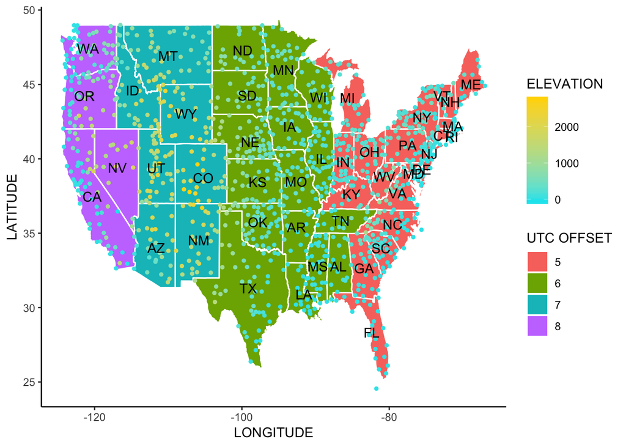

```r
states_map <- map_data("state")
weather %>% group_by(STATE) %>% summarise(state=unique(STATE),long=mean(LONGITUDE),lat=mean(LATITUDE)) -> state_summ
weather %>% select(LONGITUDE,LATITUDE,STATE,`UTC OFFSET`) %>% mutate(STATE=abbr2state(STATE)) -> state_utc
colnames(state_utc) <- c("long","lat","region","time_zone")


ggplot()+ geom_map(data = state_utc, map=states_map, aes(fill=factor(time_zone), map_id = tolower(region))) + geom_map(data = states_map, map = states_map, aes(map_id=region),color="white", fill=NA, size=0.5) + geom_point(mapping = aes(LONGITUDE,LATITUDE,colour=ELEVATION),data=weather,size=1) + scale_color_gradient(low="turquoise2", high="gold1")+theme_classic() + geom_text(mapping = aes(long,lat, label=state),data = state_summ) + geom_label() + labs(fill="UTC OFFSET")
```

## More weather data

Download .gz file and open with tools available in R.

```r
download.file("ftp://ftp.ncdc.noaa.gov/pub/data/ushcn/v2.5/ushcn.tavg.latest.raw.tar.gz",
              destfile = "temp")
untar("temp")
files <- list.files("ushcn.v2.5.5.20190204")
```

Check the numer of files inside the file ushcn.tavg.latest.raw.tar.gz and the name of the file containing the temperature data of your home towns or Fort Dodge, IA (please specify).

```r
length(files)
```

```
## [1] 1218
```

```r
weather %>%
  filter(grepl("FORT DODGE", weather$NAME)) %>%
  select(`COUNTRY CODE `,`NETWORK CODE`,"ID PLACEHOLDERS (\"00\")","COOP ID" ) %>%
  paste(collapse = "") %>% grep(files) -> index

files[index]
```

```
## [1] "USH00132999.raw.tavg"
```

There are 1218 files inside the gz file. The name of the file containing the temperature data of Fort Dodge is “USH00132999.raw.tavg”

Here is an alternative, but very similar method:

```r
myurl <- "ftp://ftp.ncdc.noaa.gov/pub/data/ushcn/v2.5/ushcn.tavg.latest.raw.tar.gz"
mytmp <- tempfile()
download.file(myurl, mytmp)

untar(mytmp)
files <- as_tibble(list.files("ushcn.v2.5.5.20190204"))
nrow(files)
```

```
## [1] 1218
```

There are 1218 files. Do they have Canon City CO?

```r
weather %>%
  filter(STATE == "CO") %>%
  mutate_if(is.character, as.factor) %>%
  select(NAME) %>%
  summary()
```

```
##              NAME
##  BOULDER       : 1
##  CANON CITY    : 1
##  CHEESMAN      : 1
##  CHEYENNE WELLS: 1
##  COLLBRAN      : 1
##  DEL NORTE 2E  : 1
##  (Other)       :18
```

Yes they do! NOTE: paste(collapse = “-”) is cool.

```r
mycanon <-
  weather %>%
  filter(NAME == "CANON CITY") %>%
  select("COUNTRY CODE " , "NETWORK CODE", "ID PLACEHOLDERS (\"00\")", "COOP ID") %>%
  paste(collapse = "")
```

Is that file in the things we downloaded?

```r
files %>%
  filter(value == paste(mycanon, "raw", "tavg", sep = "."))
```

```
## # A tibble: 1 x 1
##   value
##   <chr>
## 1 USH00051294.raw.tavg
```

## Brianna’s Response to deliverable 1 & 2

Deliverable (1): what is the last word in chapter 15? - You don’t have to answer this question, if things don’t work, but please answer the next one and see the next page. –FAILED! Error occured. Would NOT KNIT!

Deliverable (2): Write a paragraph on the biggest problem you encountered when you were building the book, and how you managed to solve it.

1st Error: had to install the `bookdown` package

2nd Error: had to install and update `namespace` package

3rd Error: had to download/install the `digest` and `RcPP` package

4th Error: had to install `stringi` package

5th Error: had to install `backports` package

6th Error: had to install `lobstr` package

7th Error: had to install `testthat` package

I tried to knitt the `README.rmd` file but then an error output.See below.

8th Error: gave a warning message stating: “package `rlang` was built under R version 3.5.2” so I doubled-clicked the error message to see where the problem occured and ran that chunk of code then deleted a few lines of code that was causing error–probably not the best way to attack this but it worked!

9th Error: had to install `emo` package but `emo` package was not found under CRAN– tools>install packages So then I searched online for `emo` package and found Hadley’s `emo` repo at: `https://github.com/hadley/emo` I followed the directions (below) and inserted the below code where it said my error occured but still no success.

You can install `emo` from github with: `install.packages("devtools")` `devtools::install_github("hadley/emo")`

10th Error: could not find tools necessary to compile a package

Tried to install Rtools but did not work; still failed to knit `READ.rmd` file